# Risk Factor Analysis

## Outcome Variable

**Outcome Variable:** y_rate_len

## Predictor Variables

**Intervention Variable:** trth2o

**Adjustment Set:**

- arm
- sex
- W_mage
- meducyrs
- feducyrs
- hhwealth_quart
- hfoodsec
- W_mhtcm
- W_mwtkg
- W_mbmi
- W_nrooms
- W_nhh
- W_nchldlt5
- brthmon
- cleanck
- impfloor
- impsan
- safeh20
- delta_meducyrs
- delta_feducyrs
- delta_hhwealth_quart
- delta_hfoodsec
- delta_W_mhtcm
- delta_W_mwtkg
- delta_W_mbmi
- delta_W_nrooms
- delta_W_nhh
- delta_W_nchldlt5
- delta_brthmon
- delta_cleanck
- delta_impfloor
- delta_impsan
- delta_safeh20

## Stratifying Variables

The analysis was stratified on these variable(s):

- agecat
- studyid
- country

## Data Summary

| agecat | studyid | country | trth2o | n_cell | n | outcome_variable |
| --- | --- | --- | --- | --- | --- | --- |
| 0-3 months | ki0047075b-MAL-ED | BANGLADESH | 1 | 132 | 134 | y_rate_len |
| 0-3 months | ki0047075b-MAL-ED | BANGLADESH | 0 | 2 | 134 | y_rate_len |
| 0-3 months | ki0047075b-MAL-ED | BRAZIL | 1 | 11 | 82 | y_rate_len |
| 0-3 months | ki0047075b-MAL-ED | BRAZIL | 0 | 71 | 82 | y_rate_len |
| 0-3 months | ki0047075b-MAL-ED | INDIA | 1 | 2 | 5 | y_rate_len |
| 0-3 months | ki0047075b-MAL-ED | INDIA | 0 | 3 | 5 | y_rate_len |
| 0-3 months | ki0047075b-MAL-ED | NEPAL | 1 | 45 | 55 | y_rate_len |
| 0-3 months | ki0047075b-MAL-ED | NEPAL | 0 | 10 | 55 | y_rate_len |
| 0-3 months | ki0047075b-MAL-ED | PERU | 1 | 36 | 45 | y_rate_len |
| 0-3 months | ki0047075b-MAL-ED | PERU | 0 | 9 | 45 | y_rate_len |
| 0-3 months | ki0047075b-MAL-ED | SOUTH AFRICA | 1 | 1 | 9 | y_rate_len |
| 0-3 months | ki0047075b-MAL-ED | SOUTH AFRICA | 0 | 8 | 9 | y_rate_len |
| 0-3 months | ki0047075b-MAL-ED | TANZANIA, UNITED REPUBLIC OF | 1 | 6 | 38 | y_rate_len |
| 0-3 months | ki0047075b-MAL-ED | TANZANIA, UNITED REPUBLIC OF | 0 | 32 | 38 | y_rate_len |
| 0-3 months | ki1000108-CMC-V-BCS-2002 | INDIA | 1 | 25 | 25 | y_rate_len |
| 0-3 months | ki1000108-CMC-V-BCS-2002 | INDIA | 0 | 0 | 25 | y_rate_len |
| 0-3 months | ki1000108-IRC | INDIA | 1 | 118 | 118 | y_rate_len |
| 0-3 months | ki1000108-IRC | INDIA | 0 | 0 | 118 | y_rate_len |
| 0-3 months | ki1017093b-PROVIDE | BANGLADESH | 1 | 14 | 640 | y_rate_len |
| 0-3 months | ki1017093b-PROVIDE | BANGLADESH | 0 | 626 | 640 | y_rate_len |
| 0-3 months | ki1017093c-NIH-Crypto | BANGLADESH | 1 | 402 | 721 | y_rate_len |
| 0-3 months | ki1017093c-NIH-Crypto | BANGLADESH | 0 | 319 | 721 | y_rate_len |
| 0-3 months | ki1113344-GMS-Nepal | NEPAL | 1 | 1 | 4 | y_rate_len |
| 0-3 months | ki1113344-GMS-Nepal | NEPAL | 0 | 3 | 4 | y_rate_len |
| 3-6 months | ki0047075b-MAL-ED | BANGLADESH | 1 | 130 | 132 | y_rate_len |
| 3-6 months | ki0047075b-MAL-ED | BANGLADESH | 0 | 2 | 132 | y_rate_len |
| 3-6 months | ki0047075b-MAL-ED | BRAZIL | 1 | 13 | 103 | y_rate_len |
| 3-6 months | ki0047075b-MAL-ED | BRAZIL | 0 | 90 | 103 | y_rate_len |
| 3-6 months | ki0047075b-MAL-ED | INDIA | 1 | 3 | 7 | y_rate_len |
| 3-6 months | ki0047075b-MAL-ED | INDIA | 0 | 4 | 7 | y_rate_len |

[output cut: 162 more lines]

The following strata were considered:

- agecat: 0-3 months, studyid: ki0047075b-MAL-ED, country: BANGLADESH
- agecat: 0-3 months, studyid: ki0047075b-MAL-ED, country: BRAZIL
- agecat: 0-3 months, studyid: ki0047075b-MAL-ED, country: INDIA
- agecat: 0-3 months, studyid: ki0047075b-MAL-ED, country: NEPAL
- agecat: 0-3 months, studyid: ki0047075b-MAL-ED, country: PERU
- agecat: 0-3 months, studyid: ki0047075b-MAL-ED, country: SOUTH AFRICA
- agecat: 0-3 months, studyid: ki0047075b-MAL-ED, country: TANZANIA, UNITED REPUBLIC OF
- agecat: 0-3 months, studyid: ki1000108-CMC-V-BCS-2002, country: INDIA
- agecat: 0-3 months, studyid: ki1000108-IRC, country: INDIA
- agecat: 0-3 months, studyid: ki1017093b-PROVIDE, country: BANGLADESH
- agecat: 0-3 months, studyid: ki1017093c-NIH-Crypto, country: BANGLADESH
- agecat: 0-3 months, studyid: ki1113344-GMS-Nepal, country: NEPAL
- agecat: 12-15 months, studyid: ki0047075b-MAL-ED, country: BANGLADESH
- agecat: 12-15 months, studyid: ki0047075b-MAL-ED, country: BRAZIL
- agecat: 12-15 months, studyid: ki0047075b-MAL-ED, country: INDIA
- agecat: 12-15 months, studyid: ki0047075b-MAL-ED, country: NEPAL
- agecat: 12-15 months, studyid: ki0047075b-MAL-ED, country: PERU
- agecat: 12-15 months, studyid: ki0047075b-MAL-ED, country: SOUTH AFRICA
- agecat: 12-15 months, studyid: ki0047075b-MAL-ED, country: TANZANIA, UNITED REPUBLIC OF
- agecat: 12-15 months, studyid: ki1000108-CMC-V-BCS-2002, country: INDIA
- agecat: 12-15 months, studyid: ki1000108-IRC, country: INDIA
- agecat: 12-15 months, studyid: ki1017093b-PROVIDE, country: BANGLADESH
- agecat: 12-15 months, studyid: ki1017093c-NIH-Crypto, country: BANGLADESH
- agecat: 12-15 months, studyid: ki1113344-GMS-Nepal, country: NEPAL
- agecat: 15-18 months, studyid: ki0047075b-MAL-ED, country: BANGLADESH
- agecat: 15-18 months, studyid: ki0047075b-MAL-ED, country: BRAZIL
- agecat: 15-18 months, studyid: ki0047075b-MAL-ED, country: INDIA
- agecat: 15-18 months, studyid: ki0047075b-MAL-ED, country: NEPAL
- agecat: 15-18 months, studyid: ki0047075b-MAL-ED, country: PERU
- agecat: 15-18 months, studyid: ki0047075b-MAL-ED, country: SOUTH AFRICA
- agecat: 15-18 months, studyid: ki0047075b-MAL-ED, country: TANZANIA, UNITED REPUBLIC OF
- agecat: 15-18 months, studyid: ki1000108-CMC-V-BCS-2002, country: INDIA
- agecat: 15-18 months, studyid: ki1000108-IRC, country: INDIA
- agecat: 15-18 months, studyid: ki1017093b-PROVIDE, country: BANGLADESH
- agecat: 15-18 months, studyid: ki1017093c-NIH-Crypto, country: BANGLADESH
- agecat: 15-18 months, studyid: ki1113344-GMS-Nepal, country: NEPAL
- agecat: 18-21 months, studyid: ki0047075b-MAL-ED, country: BANGLADESH
- agecat: 18-21 months, studyid: ki0047075b-MAL-ED, country: BRAZIL
- agecat: 18-21 months, studyid: ki0047075b-MAL-ED, country: INDIA
- agecat: 18-21 months, studyid: ki0047075b-MAL-ED, country: NEPAL
- agecat: 18-21 months, studyid: ki0047075b-MAL-ED, country: PERU
- agecat: 18-21 months, studyid: ki0047075b-MAL-ED, country: SOUTH AFRICA
- agecat: 18-21 months, studyid: ki0047075b-MAL-ED, country: TANZANIA, UNITED REPUBLIC OF
- agecat: 18-21 months, studyid: ki1000108-CMC-V-BCS-2002, country: INDIA
- agecat: 18-21 months, studyid: ki1000108-IRC, country: INDIA
- agecat: 18-21 months, studyid: ki1017093b-PROVIDE, country: BANGLADESH
- agecat: 18-21 months, studyid: ki1017093c-NIH-Crypto, country: BANGLADESH
- agecat: 18-21 months, studyid: ki1113344-GMS-Nepal, country: NEPAL
- agecat: 21-24 months, studyid: ki0047075b-MAL-ED, country: BANGLADESH
- agecat: 21-24 months, studyid: ki0047075b-MAL-ED, country: BRAZIL
- agecat: 21-24 months, studyid: ki0047075b-MAL-ED, country: INDIA
- agecat: 21-24 months, studyid: ki0047075b-MAL-ED, country: NEPAL
- agecat: 21-24 months, studyid: ki0047075b-MAL-ED, country: PERU
- agecat: 21-24 months, studyid: ki0047075b-MAL-ED, country: SOUTH AFRICA
- agecat: 21-24 months, studyid: ki0047075b-MAL-ED, country: TANZANIA, UNITED REPUBLIC OF
- agecat: 21-24 months, studyid: ki1000108-CMC-V-BCS-2002, country: INDIA
- agecat: 21-24 months, studyid: ki1000108-IRC, country: INDIA
- agecat: 21-24 months, studyid: ki1017093b-PROVIDE, country: BANGLADESH
- agecat: 21-24 months, studyid: ki1017093c-NIH-Crypto, country: BANGLADESH
- agecat: 21-24 months, studyid: ki1113344-GMS-Nepal, country: NEPAL
- agecat: 3-6 months, studyid: ki0047075b-MAL-ED, country: BANGLADESH
- agecat: 3-6 months, studyid: ki0047075b-MAL-ED, country: BRAZIL
- agecat: 3-6 months, studyid: ki0047075b-MAL-ED, country: INDIA
- agecat: 3-6 months, studyid: ki0047075b-MAL-ED, country: NEPAL
- agecat: 3-6 months, studyid: ki0047075b-MAL-ED, country: PERU
- agecat: 3-6 months, studyid: ki0047075b-MAL-ED, country: SOUTH AFRICA
- agecat: 3-6 months, studyid: ki0047075b-MAL-ED, country: TANZANIA, UNITED REPUBLIC OF
- agecat: 3-6 months, studyid: ki1000108-CMC-V-BCS-2002, country: INDIA
- agecat: 3-6 months, studyid: ki1000108-IRC, country: INDIA
- agecat: 3-6 months, studyid: ki1017093b-PROVIDE, country: BANGLADESH
- agecat: 3-6 months, studyid: ki1017093c-NIH-Crypto, country: BANGLADESH
- agecat: 3-6 months, studyid: ki1113344-GMS-Nepal, country: NEPAL
- agecat: 6-9 months, studyid: ki0047075b-MAL-ED, country: BANGLADESH
- agecat: 6-9 months, studyid: ki0047075b-MAL-ED, country: BRAZIL
- agecat: 6-9 months, studyid: ki0047075b-MAL-ED, country: INDIA
- agecat: 6-9 months, studyid: ki0047075b-MAL-ED, country: NEPAL
- agecat: 6-9 months, studyid: ki0047075b-MAL-ED, country: PERU
- agecat: 6-9 months, studyid: ki0047075b-MAL-ED, country: SOUTH AFRICA
- agecat: 6-9 months, studyid: ki0047075b-MAL-ED, country: TANZANIA, UNITED REPUBLIC OF
- agecat: 6-9 months, studyid: ki1000108-CMC-V-BCS-2002, country: INDIA
- agecat: 6-9 months, studyid: ki1000108-IRC, country: INDIA
- agecat: 6-9 months, studyid: ki1017093b-PROVIDE, country: BANGLADESH
- agecat: 6-9 months, studyid: ki1017093c-NIH-Crypto, country: BANGLADESH
- agecat: 6-9 months, studyid: ki1113344-GMS-Nepal, country: NEPAL
- agecat: 9-12 months, studyid: ki0047075b-MAL-ED, country: BANGLADESH
- agecat: 9-12 months, studyid: ki0047075b-MAL-ED, country: BRAZIL
- agecat: 9-12 months, studyid: ki0047075b-MAL-ED, country: INDIA
- agecat: 9-12 months, studyid: ki0047075b-MAL-ED, country: NEPAL
- agecat: 9-12 months, studyid: ki0047075b-MAL-ED, country: PERU
- agecat: 9-12 months, studyid: ki0047075b-MAL-ED, country: SOUTH AFRICA
- agecat: 9-12 months, studyid: ki0047075b-MAL-ED, country: TANZANIA, UNITED REPUBLIC OF
- agecat: 9-12 months, studyid: ki1000108-CMC-V-BCS-2002, country: INDIA
- agecat: 9-12 months, studyid: ki1000108-IRC, country: INDIA
- agecat: 9-12 months, studyid: ki1017093b-PROVIDE, country: BANGLADESH
- agecat: 9-12 months, studyid: ki1017093c-NIH-Crypto, country: BANGLADESH
- agecat: 9-12 months, studyid: ki1113344-GMS-Nepal, country: NEPAL

### Dropped Strata

Some strata were dropped due to rare outcomes:

- agecat: 0-3 months, studyid: ki0047075b-MAL-ED, country: BANGLADESH
- agecat: 0-3 months, studyid: ki0047075b-MAL-ED, country: INDIA
- agecat: 0-3 months, studyid: ki0047075b-MAL-ED, country: SOUTH AFRICA
- agecat: 0-3 months, studyid: ki1000108-CMC-V-BCS-2002, country: INDIA
- agecat: 0-3 months, studyid: ki1000108-IRC, country: INDIA
- agecat: 0-3 months, studyid: ki1113344-GMS-Nepal, country: NEPAL
- agecat: 3-6 months, studyid: ki0047075b-MAL-ED, country: BANGLADESH
- agecat: 3-6 months, studyid: ki0047075b-MAL-ED, country: INDIA
- agecat: 3-6 months, studyid: ki0047075b-MAL-ED, country: SOUTH AFRICA
- agecat: 3-6 months, studyid: ki1000108-CMC-V-BCS-2002, country: INDIA
- agecat: 3-6 months, studyid: ki1000108-IRC, country: INDIA
- agecat: 3-6 months, studyid: ki1113344-GMS-Nepal, country: NEPAL
- agecat: 6-9 months, studyid: ki0047075b-MAL-ED, country: BANGLADESH
- agecat: 6-9 months, studyid: ki0047075b-MAL-ED, country: INDIA
- agecat: 6-9 months, studyid: ki0047075b-MAL-ED, country: SOUTH AFRICA
- agecat: 6-9 months, studyid: ki1000108-CMC-V-BCS-2002, country: INDIA
- agecat: 6-9 months, studyid: ki1000108-IRC, country: INDIA
- agecat: 6-9 months, studyid: ki1113344-GMS-Nepal, country: NEPAL
- agecat: 9-12 months, studyid: ki0047075b-MAL-ED, country: BANGLADESH
- agecat: 9-12 months, studyid: ki0047075b-MAL-ED, country: INDIA
- agecat: 9-12 months, studyid: ki0047075b-MAL-ED, country: SOUTH AFRICA
- agecat: 9-12 months, studyid: ki1000108-CMC-V-BCS-2002, country: INDIA
- agecat: 9-12 months, studyid: ki1000108-IRC, country: INDIA
- agecat: 9-12 months, studyid: ki1113344-GMS-Nepal, country: NEPAL
- agecat: 12-15 months, studyid: ki0047075b-MAL-ED, country: BANGLADESH
- agecat: 12-15 months, studyid: ki0047075b-MAL-ED, country: INDIA
- agecat: 12-15 months, studyid: ki0047075b-MAL-ED, country: SOUTH AFRICA
- agecat: 12-15 months, studyid: ki1000108-CMC-V-BCS-2002, country: INDIA
- agecat: 12-15 months, studyid: ki1000108-IRC, country: INDIA
- agecat: 12-15 months, studyid: ki1113344-GMS-Nepal, country: NEPAL
- agecat: 15-18 months, studyid: ki0047075b-MAL-ED, country: BANGLADESH
- agecat: 15-18 months, studyid: ki0047075b-MAL-ED, country: INDIA
- agecat: 15-18 months, studyid: ki0047075b-MAL-ED, country: SOUTH AFRICA
- agecat: 15-18 months, studyid: ki1000108-CMC-V-BCS-2002, country: INDIA
- agecat: 15-18 months, studyid: ki1000108-IRC, country: INDIA
- agecat: 15-18 months, studyid: ki1113344-GMS-Nepal, country: NEPAL
- agecat: 18-21 months, studyid: ki0047075b-MAL-ED, country: BANGLADESH
- agecat: 18-21 months, studyid: ki0047075b-MAL-ED, country: INDIA
- agecat: 18-21 months, studyid: ki0047075b-MAL-ED, country: SOUTH AFRICA
- agecat: 18-21 months, studyid: ki1000108-CMC-V-BCS-2002, country: INDIA
- agecat: 18-21 months, studyid: ki1000108-IRC, country: INDIA
- agecat: 18-21 months, studyid: ki1113344-GMS-Nepal, country: NEPAL
- agecat: 21-24 months, studyid: ki0047075b-MAL-ED, country: BANGLADESH
- agecat: 21-24 months, studyid: ki0047075b-MAL-ED, country: INDIA
- agecat: 21-24 months, studyid: ki0047075b-MAL-ED, country: SOUTH AFRICA
- agecat: 21-24 months, studyid: ki1000108-CMC-V-BCS-2002, country: INDIA
- agecat: 21-24 months, studyid: ki1000108-IRC, country: INDIA
- agecat: 21-24 months, studyid: ki1113344-GMS-Nepal, country: NEPAL

## Methods Detail

We’re interested in the causal parameters $E[Y_a]$ for all values of $a \in \mathcal{A}$. These parameters represent the mean outcome if, possibly contrary to fact, we intervened to set all units to have $A=a$. Under the randomization and positivity assumptions, these are identified by the statistical parameters $\psi_a=E_W[E_{Y|A,W}(Y|A=a,W)]$. In addition, we’re interested in the mean of $Y$, $E[Y]$ under no intervention (the observed mean). We will estimate these parameters by using SuperLearner to fit the relevant likelihood factors – $E_{Y|A,W}(Y|A=a,W)$ and $p(A=a|W)$, and then updating our likelihood fit using a joint TMLE.

For unadjusted analyses ($W=\{\}$), initial likelihoods were estimated using Lrnr_glm to estimate the simple $E(Y|A)$ and Lrnr_mean to estimate $p(A)$. For adjusted analyses, a small library containing Lrnr_glmnet, Lrnr_xgboost, and Lrnr_mean was used.

Having estimated these parameters, we will then use the delta method to estimate relative risks and attributable risks relative to a prespecified baseline level of $A$.

# Results Detail

## Results Plots

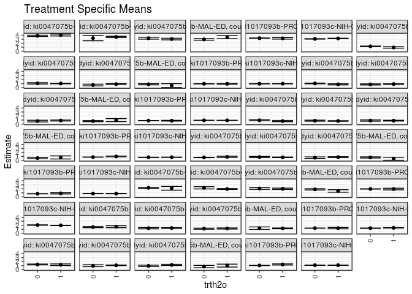

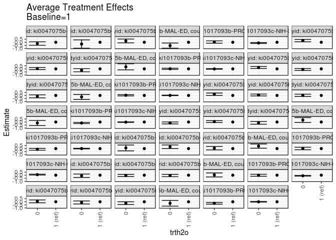

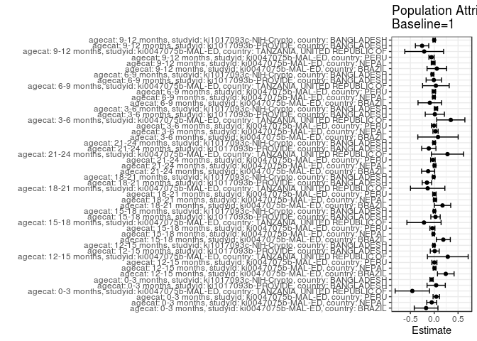

## Results Table

### Parameter: TSM

| agecat | studyid | country | intervention_level | baseline_level | estimate | ci_lower | ci_upper |
| --- | --- | --- | --- | --- | --- | --- | --- |
| 0-3 months | ki0047075b-MAL-ED | BRAZIL | 1 | NA | 4.0293184 | 3.7945765 | 4.2640602 |
| 0-3 months | ki0047075b-MAL-ED | BRAZIL | 0 | NA | 3.8261875 | 3.6683757 | 3.9839993 |
| 0-3 months | ki0047075b-MAL-ED | NEPAL | 1 | NA | 3.5552814 | 3.3941364 | 3.7164265 |
| 0-3 months | ki0047075b-MAL-ED | NEPAL | 0 | NA | 3.2668346 | 2.6081564 | 3.9255127 |
| 0-3 months | ki0047075b-MAL-ED | PERU | 1 | NA | 3.0273565 | 2.8251714 | 3.2295415 |
| 0-3 months | ki0047075b-MAL-ED | PERU | 0 | NA | 3.2438992 | 3.0076078 | 3.4801905 |
| 0-3 months | ki0047075b-MAL-ED | TANZANIA, UNITED REPUBLIC OF | 1 | NA | 3.4897230 | 3.1171369 | 3.8623092 |
| 0-3 months | ki0047075b-MAL-ED | TANZANIA, UNITED REPUBLIC OF | 0 | NA | 2.9447033 | 2.7483050 | 3.1411017 |
| 0-3 months | ki1017093b-PROVIDE | BANGLADESH | 1 | NA | 3.2166441 | 3.0240998 | 3.4091885 |
| 0-3 months | ki1017093b-PROVIDE | BANGLADESH | 0 | NA | 3.2584223 | 3.2207886 | 3.2960560 |
| 0-3 months | ki1017093c-NIH-Crypto | BANGLADESH | 1 | NA | 3.1854191 | 3.1324198 | 3.2384184 |
| 0-3 months | ki1017093c-NIH-Crypto | BANGLADESH | 0 | NA | 3.0684139 | 3.0177845 | 3.1190432 |
| 3-6 months | ki0047075b-MAL-ED | BRAZIL | 1 | NA | 2.1404710 | 1.6759812 | 2.6049607 |
| 3-6 months | ki0047075b-MAL-ED | BRAZIL | 0 | NA | 2.2521094 | 2.1434144 | 2.3608044 |
| 3-6 months | ki0047075b-MAL-ED | NEPAL | 1 | NA | 1.9577375 | 1.8477642 | 2.0677109 |
| 3-6 months | ki0047075b-MAL-ED | NEPAL | 0 | NA | 2.2557764 | 1.9779052 | 2.5336476 |
| 3-6 months | ki0047075b-MAL-ED | PERU | 1 | NA | 2.0109912 | 1.8377829 | 2.1841994 |
| 3-6 months | ki0047075b-MAL-ED | PERU | 0 | NA | 2.0831419 | 1.8709579 | 2.2953260 |
| 3-6 months | ki0047075b-MAL-ED | TANZANIA, UNITED REPUBLIC OF | 1 | NA | 1.4680425 | 1.1592662 | 1.7768187 |
| 3-6 months | ki0047075b-MAL-ED | TANZANIA, UNITED REPUBLIC OF | 0 | NA | 1.8739708 | 1.7296439 | 2.0182977 |
| 3-6 months | ki1017093b-PROVIDE | BANGLADESH | 1 | NA | 1.9526483 | 1.7499089 | 2.1553877 |
| 3-6 months | ki1017093b-PROVIDE | BANGLADESH | 0 | NA | 1.9712879 | 1.9369790 | 2.0055968 |
| 3-6 months | ki1017093c-NIH-Crypto | BANGLADESH | 1 | NA | 1.9685295 | 1.9194267 | 2.0176322 |
| 3-6 months | ki1017093c-NIH-Crypto | BANGLADESH | 0 | NA | 2.0577736 | 2.0016179 | 2.1139293 |
| 6-9 months | ki0047075b-MAL-ED | BRAZIL | 1 | NA | 1.6341600 | 1.3903274 | 1.8779926 |
| 6-9 months | ki0047075b-MAL-ED | BRAZIL | 0 | NA | 1.5387303 | 1.3989305 | 1.6785302 |
| 6-9 months | ki0047075b-MAL-ED | NEPAL | 1 | NA | 1.3179306 | 1.2362045 | 1.3996568 |
| 6-9 months | ki0047075b-MAL-ED | NEPAL | 0 | NA | 1.2737468 | 1.1107048 | 1.4367889 |
| 6-9 months | ki0047075b-MAL-ED | PERU | 1 | NA | 1.2000876 | 1.0631434 | 1.3370318 |
| 6-9 months | ki0047075b-MAL-ED | PERU | 0 | NA | 1.1472026 | 1.0120541 | 1.2823512 |

[output cut: 66 more lines]

### Parameter: E(Y)

| agecat | studyid | country | intervention_level | baseline_level | estimate | ci_lower | ci_upper |
| --- | --- | --- | --- | --- | --- | --- | --- |
| 0-3 months | ki0047075b-MAL-ED | BRAZIL | NA | NA | 3.8592466 | 3.7187660 | 3.9997272 |
| 0-3 months | ki0047075b-MAL-ED | NEPAL | NA | NA | 3.5026449 | 3.3476789 | 3.6576109 |
| 0-3 months | ki0047075b-MAL-ED | PERU | NA | NA | 3.0706650 | 2.9002220 | 3.2411079 |
| 0-3 months | ki0047075b-MAL-ED | TANZANIA, UNITED REPUBLIC OF | NA | NA | 3.0307591 | 2.8439041 | 3.2176140 |
| 0-3 months | ki1017093b-PROVIDE | BANGLADESH | NA | NA | 3.2576810 | 3.2206777 | 3.2946843 |
| 0-3 months | ki1017093c-NIH-Crypto | BANGLADESH | NA | NA | 3.1292449 | 3.0928504 | 3.1656393 |
| 3-6 months | ki0047075b-MAL-ED | BRAZIL | NA | NA | 2.2197131 | 2.1101066 | 2.3293196 |
| 3-6 months | ki0047075b-MAL-ED | NEPAL | NA | NA | 1.9853011 | 1.8803268 | 2.0902754 |
| 3-6 months | ki0047075b-MAL-ED | PERU | NA | NA | 2.0060188 | 1.8634433 | 2.1485943 |
| 3-6 months | ki0047075b-MAL-ED | TANZANIA, UNITED REPUBLIC OF | NA | NA | 1.8159811 | 1.6776334 | 1.9543288 |
| 3-6 months | ki1017093b-PROVIDE | BANGLADESH | NA | NA | 1.9657457 | 1.9318660 | 1.9996254 |
| 3-6 months | ki1017093c-NIH-Crypto | BANGLADESH | NA | NA | 2.0057973 | 1.9693775 | 2.0422170 |
| 6-9 months | ki0047075b-MAL-ED | BRAZIL | NA | NA | 1.5419552 | 1.4161616 | 1.6677488 |
| 6-9 months | ki0047075b-MAL-ED | NEPAL | NA | NA | 1.3116074 | 1.2397407 | 1.3834741 |
| 6-9 months | ki0047075b-MAL-ED | PERU | NA | NA | 1.1939434 | 1.0843398 | 1.3035471 |
| 6-9 months | ki0047075b-MAL-ED | TANZANIA, UNITED REPUBLIC OF | NA | NA | 1.2629098 | 0.9955016 | 1.5303180 |
| 6-9 months | ki1017093b-PROVIDE | BANGLADESH | NA | NA | 1.2824185 | 1.2571827 | 1.3076542 |
| 6-9 months | ki1017093c-NIH-Crypto | BANGLADESH | NA | NA | 1.3282695 | 1.2988292 | 1.3577098 |
| 9-12 months | ki0047075b-MAL-ED | BRAZIL | NA | NA | 1.2896896 | 1.1901580 | 1.3892213 |
| 9-12 months | ki0047075b-MAL-ED | NEPAL | NA | NA | 1.0747092 | 1.0020180 | 1.1474004 |
| 9-12 months | ki0047075b-MAL-ED | PERU | NA | NA | 1.1281439 | 1.0053147 | 1.2509730 |
| 9-12 months | ki0047075b-MAL-ED | TANZANIA, UNITED REPUBLIC OF | NA | NA | 0.8117127 | 0.5485045 | 1.0749209 |
| 9-12 months | ki1017093b-PROVIDE | BANGLADESH | NA | NA | 1.0499750 | 1.0230130 | 1.0769370 |
| 9-12 months | ki1017093c-NIH-Crypto | BANGLADESH | NA | NA | 1.1234745 | 1.0972274 | 1.1497215 |
| 12-15 months | ki0047075b-MAL-ED | BRAZIL | NA | NA | 1.1769612 | 1.1045524 | 1.2493699 |
| 12-15 months | ki0047075b-MAL-ED | NEPAL | NA | NA | 1.0278956 | 0.9678283 | 1.0879630 |
| 12-15 months | ki0047075b-MAL-ED | PERU | NA | NA | 0.8783001 | 0.7638220 | 0.9927782 |
| 12-15 months | ki0047075b-MAL-ED | TANZANIA, UNITED REPUBLIC OF | NA | NA | 0.7956749 | 0.6519279 | 0.9394219 |
| 12-15 months | ki1017093b-PROVIDE | BANGLADESH | NA | NA | 0.9597501 | 0.9335899 | 0.9859102 |
| 12-15 months | ki1017093c-NIH-Crypto | BANGLADESH | NA | NA | 0.9711395 | 0.9465805 | 0.9956985 |
| 15-18 months | ki0047075b-MAL-ED | BRAZIL | NA | NA | 1.0078031 | 0.9251335 | 1.0904728 |
| 15-18 months | ki0047075b-MAL-ED | NEPAL | NA | NA | 0.8737133 | 0.8117853 | 0.9356414 |
| 15-18 months | ki0047075b-MAL-ED | PERU | NA | NA | 0.8383703 | 0.7329602 | 0.9437805 |
| 15-18 months | ki0047075b-MAL-ED | TANZANIA, UNITED REPUBLIC OF | NA | NA | 0.7647144 | 0.6223905 | 0.9070384 |
| 15-18 months | ki1017093b-PROVIDE | BANGLADESH | NA | NA | 0.8560998 | 0.8320145 | 0.8801852 |
| 15-18 months | ki1017093c-NIH-Crypto | BANGLADESH | NA | NA | 0.9177168 | 0.8947657 | 0.9406678 |
| 18-21 months | ki0047075b-MAL-ED | BRAZIL | NA | NA | 0.9113468 | 0.8087233 | 1.0139703 |
| 18-21 months | ki0047075b-MAL-ED | NEPAL | NA | NA | 0.7759274 | 0.7112362 | 0.8406186 |
| 18-21 months | ki0047075b-MAL-ED | PERU | NA | NA | 0.8457955 | 0.7602887 | 0.9313023 |
| 18-21 months | ki0047075b-MAL-ED | TANZANIA, UNITED REPUBLIC OF | NA | NA | 0.6129126 | 0.4646003 | 0.7612249 |
| 18-21 months | ki1017093b-PROVIDE | BANGLADESH | NA | NA | 0.8393377 | 0.8153485 | 0.8633269 |
| 18-21 months | ki1017093c-NIH-Crypto | BANGLADESH | NA | NA | 0.7977755 | 0.7744353 | 0.8211158 |
| 21-24 months | ki0047075b-MAL-ED | BRAZIL | NA | NA | 0.7722472 | 0.7221195 | 0.8223749 |
| 21-24 months | ki0047075b-MAL-ED | NEPAL | NA | NA | 0.7915700 | 0.7335331 | 0.8496069 |
| 21-24 months | ki0047075b-MAL-ED | PERU | NA | NA | 0.7989125 | 0.7024314 | 0.8953937 |
| 21-24 months | ki0047075b-MAL-ED | TANZANIA, UNITED REPUBLIC OF | NA | NA | 0.7040721 | 0.5679942 | 0.8401499 |
| 21-24 months | ki1017093b-PROVIDE | BANGLADESH | NA | NA | 0.7631391 | 0.7377453 | 0.7885328 |
| 21-24 months | ki1017093c-NIH-Crypto | BANGLADESH | NA | NA | 0.7993353 | 0.7748026 | 0.8238681 |

### Parameter: ATE

| agecat | studyid | country | intervention_level | baseline_level | estimate | ci_lower | ci_upper |
| --- | --- | --- | --- | --- | --- | --- | --- |
| 0-3 months | ki0047075b-MAL-ED | BRAZIL | 1 | 1 | 0.0000000 | 0.0000000 | 0.0000000 |
| 0-3 months | ki0047075b-MAL-ED | BRAZIL | 0 | 1 | -0.2031309 | -0.4869572 | 0.0806955 |
| 0-3 months | ki0047075b-MAL-ED | NEPAL | 1 | 1 | 0.0000000 | 0.0000000 | 0.0000000 |
| 0-3 months | ki0047075b-MAL-ED | NEPAL | 0 | 1 | -0.2884469 | -0.9681800 | 0.3912863 |
| 0-3 months | ki0047075b-MAL-ED | PERU | 1 | 1 | 0.0000000 | 0.0000000 | 0.0000000 |
| 0-3 months | ki0047075b-MAL-ED | PERU | 0 | 1 | 0.2165427 | -0.0944435 | 0.5275289 |
| 0-3 months | ki0047075b-MAL-ED | TANZANIA, UNITED REPUBLIC OF | 1 | 1 | 0.0000000 | 0.0000000 | 0.0000000 |
| 0-3 months | ki0047075b-MAL-ED | TANZANIA, UNITED REPUBLIC OF | 0 | 1 | -0.5450197 | -0.9661999 | -0.1238395 |
| 0-3 months | ki1017093b-PROVIDE | BANGLADESH | 1 | 1 | 0.0000000 | 0.0000000 | 0.0000000 |
| 0-3 months | ki1017093b-PROVIDE | BANGLADESH | 0 | 1 | 0.0417782 | -0.1542013 | 0.2377577 |
| 0-3 months | ki1017093c-NIH-Crypto | BANGLADESH | 1 | 1 | 0.0000000 | 0.0000000 | 0.0000000 |
| 0-3 months | ki1017093c-NIH-Crypto | BANGLADESH | 0 | 1 | -0.1170053 | -0.1904174 | -0.0435931 |
| 3-6 months | ki0047075b-MAL-ED | BRAZIL | 1 | 1 | 0.0000000 | 0.0000000 | 0.0000000 |
| 3-6 months | ki0047075b-MAL-ED | BRAZIL | 0 | 1 | 0.1116385 | -0.3655120 | 0.5887889 |
| 3-6 months | ki0047075b-MAL-ED | NEPAL | 1 | 1 | 0.0000000 | 0.0000000 | 0.0000000 |
| 3-6 months | ki0047075b-MAL-ED | NEPAL | 0 | 1 | 0.2980389 | 0.0002993 | 0.5957784 |
| 3-6 months | ki0047075b-MAL-ED | PERU | 1 | 1 | 0.0000000 | 0.0000000 | 0.0000000 |
| 3-6 months | ki0047075b-MAL-ED | PERU | 0 | 1 | 0.0721508 | -0.2094568 | 0.3537584 |
| 3-6 months | ki0047075b-MAL-ED | TANZANIA, UNITED REPUBLIC OF | 1 | 1 | 0.0000000 | 0.0000000 | 0.0000000 |
| 3-6 months | ki0047075b-MAL-ED | TANZANIA, UNITED REPUBLIC OF | 0 | 1 | 0.4059284 | 0.0650868 | 0.7467700 |
| 3-6 months | ki1017093b-PROVIDE | BANGLADESH | 1 | 1 | 0.0000000 | 0.0000000 | 0.0000000 |
| 3-6 months | ki1017093b-PROVIDE | BANGLADESH | 0 | 1 | 0.0186396 | -0.1871151 | 0.2243943 |
| 3-6 months | ki1017093c-NIH-Crypto | BANGLADESH | 1 | 1 | 0.0000000 | 0.0000000 | 0.0000000 |
| 3-6 months | ki1017093c-NIH-Crypto | BANGLADESH | 0 | 1 | 0.0892441 | 0.0149401 | 0.1635481 |
| 6-9 months | ki0047075b-MAL-ED | BRAZIL | 1 | 1 | 0.0000000 | 0.0000000 | 0.0000000 |
| 6-9 months | ki0047075b-MAL-ED | BRAZIL | 0 | 1 | -0.0954297 | -0.3755714 | 0.1847121 |
| 6-9 months | ki0047075b-MAL-ED | NEPAL | 1 | 1 | 0.0000000 | 0.0000000 | 0.0000000 |
| 6-9 months | ki0047075b-MAL-ED | NEPAL | 0 | 1 | -0.0441838 | -0.2266297 | 0.1382621 |
| 6-9 months | ki0047075b-MAL-ED | PERU | 1 | 1 | 0.0000000 | 0.0000000 | 0.0000000 |
| 6-9 months | ki0047075b-MAL-ED | PERU | 0 | 1 | -0.0528849 | -0.2457503 | 0.1399805 |

[output cut: 66 more lines]

### Parameter: PAR

| agecat | studyid | country | intervention_level | baseline_level | estimate | ci_lower | ci_upper |
| --- | --- | --- | --- | --- | --- | --- | --- |
| 0-3 months | ki0047075b-MAL-ED | BRAZIL | 1 | NA | -0.1700718 | -0.4184060 | 0.0782624 |
| 0-3 months | ki0047075b-MAL-ED | NEPAL | 1 | NA | -0.0526366 | -0.1558596 | 0.0505865 |
| 0-3 months | ki0047075b-MAL-ED | PERU | 1 | NA | 0.0433085 | -0.0239485 | 0.1105656 |
| 0-3 months | ki0047075b-MAL-ED | TANZANIA, UNITED REPUBLIC OF | 1 | NA | -0.4589640 | -0.8193765 | -0.0985514 |
| 0-3 months | ki1017093b-PROVIDE | BANGLADESH | 1 | NA | 0.0410369 | -0.1502821 | 0.2323559 |
| 0-3 months | ki1017093c-NIH-Crypto | BANGLADESH | 1 | NA | -0.0561743 | -0.0894544 | -0.0228941 |
| 3-6 months | ki0047075b-MAL-ED | BRAZIL | 1 | NA | 0.0792421 | -0.3440247 | 0.5025090 |
| 3-6 months | ki0047075b-MAL-ED | NEPAL | 1 | NA | 0.0275635 | -0.0272120 | 0.0823391 |
| 3-6 months | ki0047075b-MAL-ED | PERU | 1 | NA | -0.0049723 | -0.0596805 | 0.0497358 |
| 3-6 months | ki0047075b-MAL-ED | TANZANIA, UNITED REPUBLIC OF | 1 | NA | 0.3479386 | 0.0525710 | 0.6433063 |
| 3-6 months | ki1017093b-PROVIDE | BANGLADESH | 1 | NA | 0.0130974 | -0.1878392 | 0.2140340 |
| 3-6 months | ki1017093c-NIH-Crypto | BANGLADESH | 1 | NA | 0.0372678 | 0.0026920 | 0.0718436 |
| 6-9 months | ki0047075b-MAL-ED | BRAZIL | 1 | NA | -0.0922048 | -0.3395571 | 0.1551474 |
| 6-9 months | ki0047075b-MAL-ED | NEPAL | 1 | NA | -0.0063232 | -0.0365925 | 0.0239460 |
| 6-9 months | ki0047075b-MAL-ED | PERU | 1 | NA | -0.0061441 | -0.0419331 | 0.0296449 |
| 6-9 months | ki0047075b-MAL-ED | TANZANIA, UNITED REPUBLIC OF | 1 | NA | 0.0351880 | -0.2440636 | 0.3144396 |
| 6-9 months | ki1017093b-PROVIDE | BANGLADESH | 1 | NA | -0.0080543 | -0.1696360 | 0.1535275 |
| 6-9 months | ki1017093c-NIH-Crypto | BANGLADESH | 1 | NA | -0.0369051 | -0.0649613 | -0.0088490 |
| 9-12 months | ki0047075b-MAL-ED | BRAZIL | 1 | NA | 0.0552509 | -0.1502681 | 0.2607699 |
| 9-12 months | ki0047075b-MAL-ED | NEPAL | 1 | NA | -0.0220925 | -0.0617870 | 0.0176019 |
| 9-12 months | ki0047075b-MAL-ED | PERU | 1 | NA | -0.0565821 | -0.1112798 | -0.0018843 |
| 9-12 months | ki0047075b-MAL-ED | TANZANIA, UNITED REPUBLIC OF | 1 | NA | -0.2098030 | -0.6164757 | 0.1968697 |
| 9-12 months | ki1017093b-PROVIDE | BANGLADESH | 1 | NA | -0.2547874 | -0.3945254 | -0.1150493 |
| 9-12 months | ki1017093c-NIH-Crypto | BANGLADESH | 1 | NA | -0.0006465 | -0.0258684 | 0.0245753 |
| 12-15 months | ki0047075b-MAL-ED | BRAZIL | 1 | NA | 0.2427299 | 0.0686225 | 0.4168373 |
| 12-15 months | ki0047075b-MAL-ED | NEPAL | 1 | NA | 0.0072106 | -0.0218170 | 0.0362381 |
| 12-15 months | ki0047075b-MAL-ED | PERU | 1 | NA | 0.0037792 | -0.0492534 | 0.0568119 |
| 12-15 months | ki0047075b-MAL-ED | TANZANIA, UNITED REPUBLIC OF | 1 | NA | 0.2848826 | -0.1423753 | 0.7121405 |
| 12-15 months | ki1017093b-PROVIDE | BANGLADESH | 1 | NA | 0.0107843 | -0.0824503 | 0.1040189 |
| 12-15 months | ki1017093c-NIH-Crypto | BANGLADESH | 1 | NA | -0.0071581 | -0.0305892 | 0.0162729 |
| 15-18 months | ki0047075b-MAL-ED | BRAZIL | 1 | NA | 0.1912489 | 0.0445059 | 0.3379919 |
| 15-18 months | ki0047075b-MAL-ED | NEPAL | 1 | NA | -0.0167001 | -0.0419260 | 0.0085258 |
| 15-18 months | ki0047075b-MAL-ED | PERU | 1 | NA | -0.0380044 | -0.0908837 | 0.0148749 |
| 15-18 months | ki0047075b-MAL-ED | TANZANIA, UNITED REPUBLIC OF | 1 | NA | -0.2141583 | -0.5727752 | 0.1444586 |
| 15-18 months | ki1017093b-PROVIDE | BANGLADESH | 1 | NA | 0.0273850 | -0.0705986 | 0.1253685 |
| 15-18 months | ki1017093c-NIH-Crypto | BANGLADESH | 1 | NA | 0.0032322 | -0.0200838 | 0.0265481 |
| 18-21 months | ki0047075b-MAL-ED | BRAZIL | 1 | NA | 0.1740803 | 0.0019007 | 0.3462600 |
| 18-21 months | ki0047075b-MAL-ED | NEPAL | 1 | NA | 0.0159129 | -0.0176368 | 0.0494627 |
| 18-21 months | ki0047075b-MAL-ED | PERU | 1 | NA | 0.0040474 | -0.0320064 | 0.0401012 |
| 18-21 months | ki0047075b-MAL-ED | TANZANIA, UNITED REPUBLIC OF | 1 | NA | -0.1369223 | -0.4974390 | 0.2235944 |
| 18-21 months | ki1017093b-PROVIDE | BANGLADESH | 1 | NA | -0.1528493 | -0.2521586 | -0.0535400 |
| 18-21 months | ki1017093c-NIH-Crypto | BANGLADESH | 1 | NA | -0.0116853 | -0.0364962 | 0.0131256 |
| 21-24 months | ki0047075b-MAL-ED | BRAZIL | 1 | NA | -0.1275095 | -0.2648232 | 0.0098042 |
| 21-24 months | ki0047075b-MAL-ED | NEPAL | 1 | NA | 0.0077250 | -0.0198201 | 0.0352702 |
| 21-24 months | ki0047075b-MAL-ED | PERU | 1 | NA | -0.0273594 | -0.0750902 | 0.0203714 |
| 21-24 months | ki0047075b-MAL-ED | TANZANIA, UNITED REPUBLIC OF | 1 | NA | 0.2788832 | -0.0592694 | 0.6170358 |
| 21-24 months | ki1017093b-PROVIDE | BANGLADESH | 1 | NA | -0.1134728 | -0.2630243 | 0.0360787 |
| 21-24 months | ki1017093c-NIH-Crypto | BANGLADESH | 1 | NA | -0.0025762 | -0.0318027 | 0.0266503 |